# TelecomChurnCapstone

## ROC

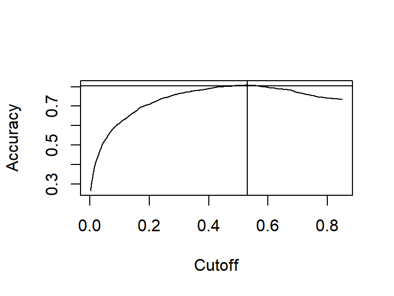

```r
##accuracy

plot(performance(ROCRpred, "acc"))
abline(h=0.805, v=0.53)
```

```r
#returns true if prediction greater than 0.5 predictsChurn and false for less than 0.5 predicts stay
table(telecomTrain$Churn,predictTrainn>0.53)
```

```
##
##       FALSE TRUE
##   No   3545  335
##   Yes   676  726
```

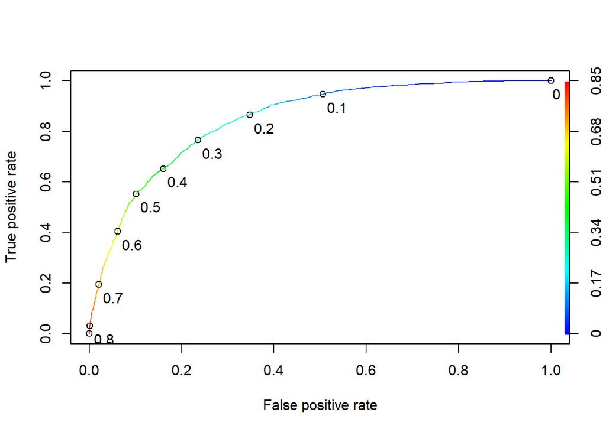

```r
#ROC Curve
ROCRpred<-prediction(predictTrainn,telecomTrain$Churn)

ROCRperf<- performance(ROCRpred, "tpr","fpr")

plot(ROCRperf, colorize=TRUE, print.cutoffs.at=seq(0,1,0.1),text.adj=c(-0.2,1.7))
```

```r
AUC<-performance(ROCRpred, "auc")
AUC<-unlist(slot(AUC,"y.values"))
AUC<-round(AUC,4)
AUC
```

```
## [1] 0.8475
```

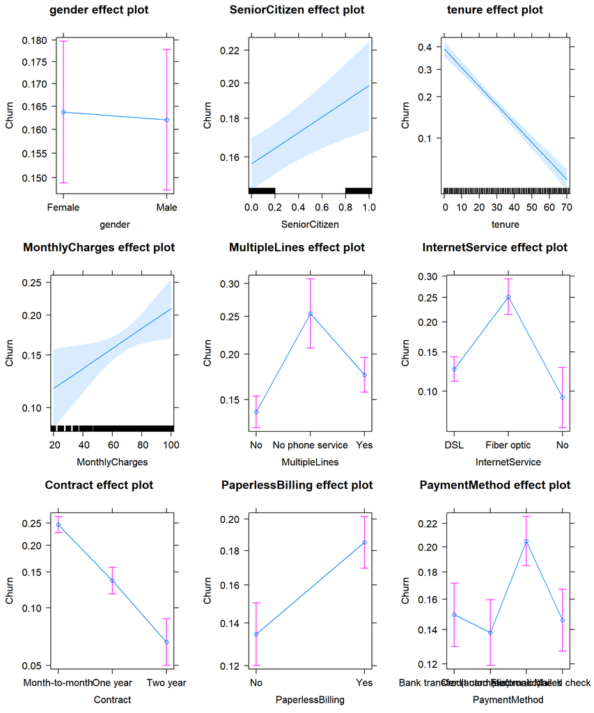

```r
churnmodel1 <- glm(Churn~gender+SeniorCitizen+tenure+MonthlyCharges+MultipleLines+InternetService+Contract+PaperlessBilling+PaymentMethod,data=telecom, family="binomial")





plot(allEffects(churnmodel1))
```

# Conclusion

The telecom customer churn analysis depicts various interesting results some of which include:  
1. Females are ~0.2% more likely to churn.  
2. Senior Citizens are ~4% likely to churn.  
3. Customers with tenure of 0 months are ~40% more likely to churn compared to customers with tenure of 72 months. Between 0 to 40 months the customer is likely to churn. The company should focus on their services during this period.  
4. Higher monthly charges to customers are more likely to churn. A customer paying $100 monthly is 1.75x more likely to churn than that of a customer paying ~$20 per month.  
5. Customers with multiple lines are 1.3x more likely to churn compared to people with no multiple lines (single line). Customers with no phone service are 1.9x more likely to churn in comparison with single line service.  
6. Customers with Fiber Optics are 2.7x more likely to churn in comparison to customers with no internet service. While DSL customers are 1.4x likely to churn compared to customers with no internet service.  
7. Month to Month customers are 3.5x more likely to churn than a two year contracted customer. While a one year contracted customer is 1.8x more likely to churn than a two year contracted customer.  
8. Customers with paperless billing are 1.37x more likely to churn than those receiving their monthly bill in the mail.  
9. Customers paying with Electronic Check are 1.4x more likely to churn in comparison to customers paying in credit card. While customers paying by bank transfer were 1.07x and customers paying by mailed check was 1.03x more likely to churn in comparison to customers paying in credit card.

# Recommendations

More research would need to be done to see if these trends are specific to this data set or can be used to speak of other telecom data sets as well. Addition of detailed variables to this data such as price of each service, the location of the customer, demography, and age of customer would help gain further insight.